# Tidy bootstrapping with dplyr+broom

Another place where combining model fits in a tidy way becomes useful is when performing bootstrapping or permutation tests. These approaches have been explored before, for instance by [Andrew MacDonald here](http://rstudio-pubs-static.s3.amazonaws.com/19698_a4c472606e3c43e4b94720506e49bb7b.html), and [Hadley has explored efficient support for bootstrapping](https://github.com/hadley/dplyr/issues/269) as a potential enhancement to dplyr. broom fits naturally with dplyr in performing these analyses.

Bootstrapping consists of randomly sampling a dataset with replacement, then performing the analysis individually on each bootstrapped replicate. The variation in the resulting estimate is then a reasonable approximation of the variance in your estimate.

Let's say you want to fit a nonlinear model to the weight/mileage relationship in the `mtcars` dataset.

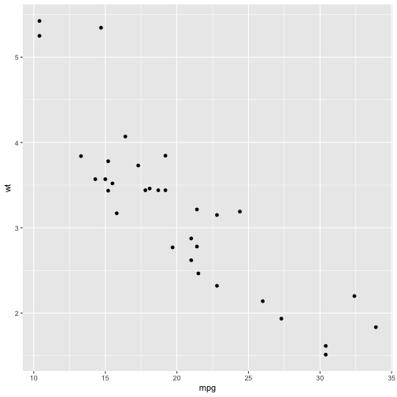

```r
library(ggplot2)
data(mtcars)
ggplot(mtcars, aes(mpg, wt)) + geom_point()
```

You might use the method of nonlinear least squares (`nls` function) to fit a model.

```r
nlsfit <- nls(mpg ~ k / wt + b, mtcars, start=list(k=1, b=0))
summary(nlsfit)
```

```
##
## Formula: mpg ~ k/wt + b
##
## Parameters:
##   Estimate Std. Error t value Pr(>|t|)
## k   45.829      4.249  10.786 7.64e-12 ***
## b    4.386      1.536   2.855  0.00774 **
## ---
## Signif. codes:  0 '***' 0.001 '**' 0.01 '*' 0.05 '.' 0.1 ' ' 1
##
## Residual standard error: 2.774 on 30 degrees of freedom
##
## Number of iterations to convergence: 1
## Achieved convergence tolerance: 2.877e-08
```

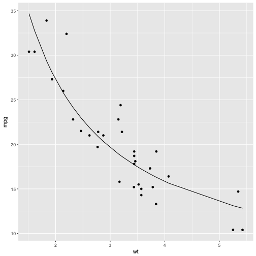

```r
ggplot(mtcars, aes(wt, mpg)) + geom_point() + geom_line(aes(y=predict(nlsfit)))
```

While this does provide a p-value and confidence intervals for the parameters, these are based on model assumptions that may not hold in real data. Bootstrapping is a popular method for providing confidence intervals and predictions that are more robust to the nature of the data. The function `bootstrap` in **broom** can be used to sample bootstrap replications. First, we construct 100 bootstrap replications of the data, each of which has been randomly sampled with replacement.

We use `do` to perform an `nls` fit on each replication, using `tidy` to recombine:

```r
library(dplyr)
library(broom)
set.seed(2014)
bootnls <- mtcars %>% bootstrap(100) %>%
    do(tidy(nls(mpg ~ k / wt + b, ., start=list(k=1, b=0))))
```

This produces a summary of each replication, combined into one data.frame:

```r
bootnls
```

```
## Source: local data frame [200 x 6]
## Groups: replicate [100]
##
##    replicate  term  estimate std.error  statistic      p.value
##        <int> <chr>     <dbl>     <dbl>      <dbl>        <dbl>
## 1          1     k 46.632502  4.026016 11.5827898 1.343891e-12
## 2          1     b  4.360637  1.538267  2.8347730 8.129583e-03
## 3          2     k 54.182476  4.964976 10.9129374 5.756829e-12
## 4          2     b  1.004868  1.897196  0.5296599 6.002460e-01
## 5          3     k 43.257212  3.564860 12.1343382 4.222953e-13
## 6          3     b  4.833510  1.297909  3.7240748 8.101899e-04
## 7          4     k 48.531351  4.456883 10.8890786 6.069158e-12
## 8          4     b  3.509346  1.688979  2.0777907 4.638415e-02
## 9          5     k 52.605099  5.662690  9.2897713 2.472139e-10
## 10         5     b  3.344380  2.300411  1.4538184 1.563791e-01
## # ... with 190 more rows
```

You can then calculate confidence intervals (using what is called the [percentile method](https://www.uvm.edu/%7Edhowell/StatPages/Randomization%20Tests/ResamplingWithR/BootstMeans/bootstrapping_means.html)):

```r
alpha = .05
bootnls %>% group_by(term) %>% summarize(low=quantile(estimate, alpha / 2),
                                         high=quantile(estimate, 1 - alpha / 2))
```

```
## # A tibble: 2 × 3
##    term       low      high
##   <chr>     <dbl>     <dbl>
## 1     b  0.214338  6.538996
## 2     k 39.725501 58.699301
```

Or you can use histograms to give you a more detailed idea of the uncertainty in each estimate:

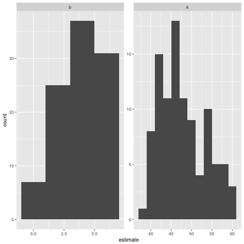

```r
library(ggplot2)
ggplot(bootnls, aes(estimate)) + geom_histogram(binwidth=2) + facet_wrap(~ term, scales="free")
```

Or you can use `augment` to visualize the uncertainty in the curve:

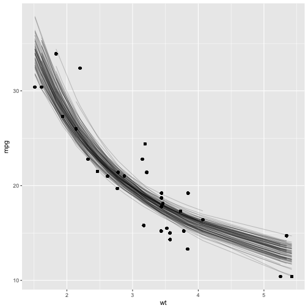

```r
bootnls_aug <- mtcars %>% bootstrap(100) %>%
    do(augment(nls(mpg ~ k / wt + b, ., start=list(k=1, b=0)), .))

ggplot(bootnls_aug, aes(wt, mpg)) + geom_point() +
    geom_line(aes(y=.fitted, group=replicate), alpha=.2)
```

With only a few small changes, one could easily perform bootstrapping with other kinds of predictive or hypothesis testing models, since the `tidy` and `augment` functions works for many statistical outputs. As another example, you could use `smooth.spline`:

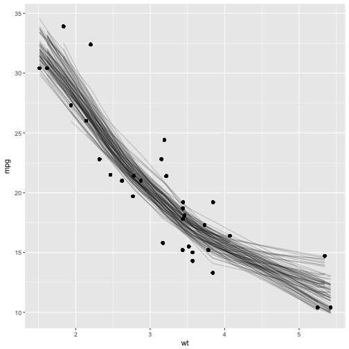

```r
smoothspline_aug <- mtcars %>% bootstrap(100) %>%
    do(augment(smooth.spline(.$wt, .$mpg, df=4), .))

ggplot(smoothspline_aug, aes(wt, mpg)) + geom_point() +
    geom_line(aes(y=.fitted, group=replicate), alpha=.2)
```